# Assignment 3

CMS2 529

Eduardo Cassinelli

Please submit a `zip` file including both the `Rmd` and `html` file produced by *knitting* this document with your modifications. Be sure to change the name of the author above.

# 1 [4 points] Forecasting unemployment benefits in Australia

- Mean
- Naive
- Seasonal naive
- Drift

Please be sure to use use a legend indicating which line corresponds to which forecast and to please turn off the prediction interval. See [Simple Methods](https://otexts.com/fpp2/simple-methods.html) for examples.

## 1.1 [4 points] Solution: Forecasting unemployment benefits in Australia

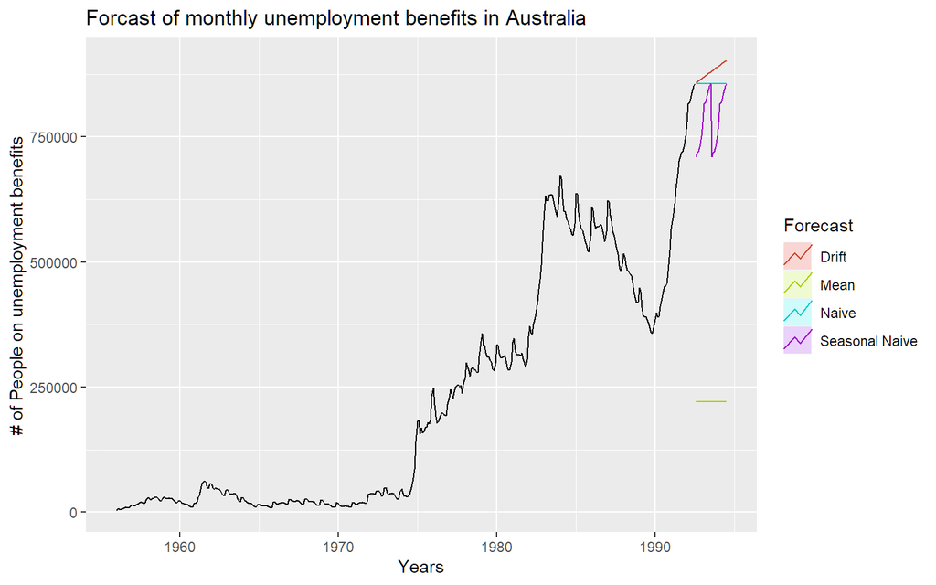

```r
autoplot(dole) +
  autolayer(meanf(dole, h=24),
            series="Mean", PI=FALSE) +
  autolayer(naive(dole, h=24),
            series="Naive", PI=FALSE) +
  autolayer(snaive(dole, h=24),
            series="Seasonal Naive", PI=FALSE) +
  autolayer(rwf(dole, drift=TRUE, h=24),
            series="Drift", PI=FALSE) +
  ggtitle("Forcast of monthly unemployment benefits in Australia") + xlab("Years") + ylab("# of People on unemployment benefits") + guides(colour=guide_legend(title="Forecast"))
```

# 2 [2 points] Transforming unemployment benefits in Australia

Please apply the Box-Cox transformation with ideal lambda value to the `dole` dataset. Plot such that both are seen along the same faceted plot. You may find the following code to be helpful:

```r
# Get help on ausbeer
?ausbeer

# Determine lambda
lambda <- BoxCox.lambda(ausbeer)

# Apply the Box-Cox transformation
ausbeer.tran <- BoxCox(ausbeer, lambda=lambda)

# Glue both the ausbeer.tran together to make them easier to plot
toPlot <- cbind(ausbeer, ausbeer.tran)

# Plot both facets
autoplot(toPlot, facet=T) +
   xlab(“Year”) +
   ggtitle("Quarterly Australian Beer production with Transformation")
```

Do you consider the Box-Cox transformation to be helpful in forecasting the `dole` dataset?

## 2.1 [2 points] Solution: Transforming unemployment benefits in Australia

```r
# Determine lambda
lambda <- BoxCox.lambda(dole)

# Apply the Box-Cox transformation
dole.tran <- BoxCox(dole, lambda=lambda)
```

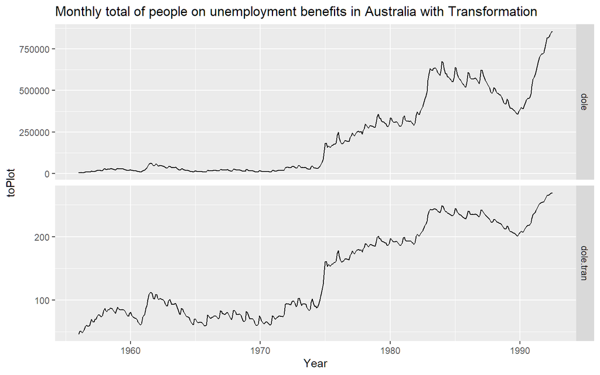

```r
# Glue both the ausbeer.tran together to make them easier to plot
toPlot <- cbind(dole, dole.tran)

# Plot both facets
autoplot(toPlot, facet=T) +
   xlab("Year") +
   ggtitle("Monthly total of people on unemployment benefits in Australia with Transformation")
```

> Do you consider the Box-Cox transformation to be helpful in forecasting the `dole` dataset?

> Yes, I do find it helpful for the forcast since it makes the variation more uniform.

# 3 [2 points] Transforming Canadian gas production

The `cangas` dataset, included n the “fpp2” library, contains monthly Canadian gas production in billions of cubic metres from January 1960 to February 2005. Please apply the Box-Cox transformation with ideal lambda value to the `cangas` dataset. Plot such that both are seen along the same faceted plot. Do you consider the Box-Cox transformation to be helpful in forecasting the `cangas` dataset?

## 3.1 [2 points] Solution: Transforming Canadian gas production

```r
# Determine lambda and transform
lambda_cangas <- BoxCox.lambda(cangas)

# Apply the Box-Cox transformation
cangas.tran <- BoxCox(cangas, lambda=lambda_cangas)
```

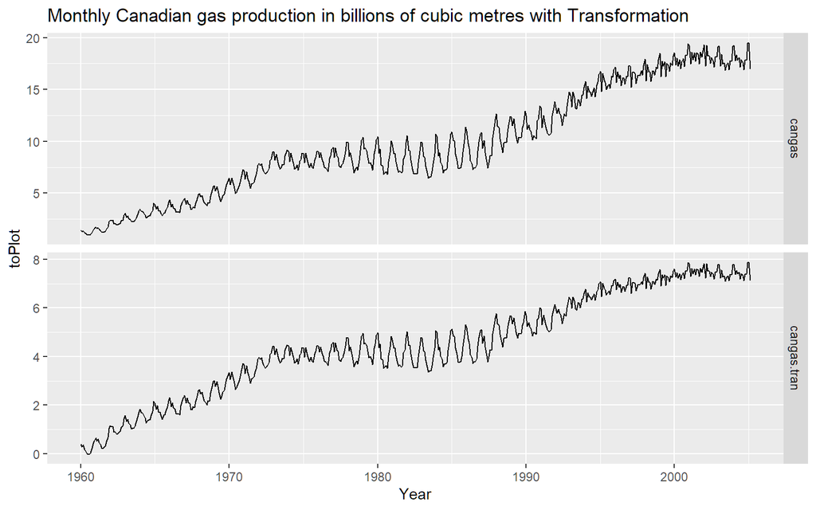

```r
# Glue both the ausbeer.tran together to make them easier to plot
toPlot <- cbind(cangas, cangas.tran)

# Plot both facets
autoplot(toPlot, facet=T) +
   xlab("Year") +
   ggtitle("Monthly Canadian gas production in billions of cubic metres with Transformation")
```

> Do you consider the Box-Cox transformation to be helpful in forecasting the `cangas` dataset?

> In this case I think it is not since the transformation does not change much the seasonality. Variation seems to be the same in both cases.

# 4 [3 points] How good is the seasonal naive forecast of Australian clay brick production?

Calculate the residuals from a seasonal naïve forecast applied to the quarterly Australian clay brick production data, `bricksq`. Additionally, test if the residuals are white noise and normally distributed. The following code will help.

```r
fc <- snaive(bricksq)
autoplot(fc)
res <- residuals(fc)
autoplot(res)
checkresiduals(fc)
```

> What can you conclude?

## 4.1 [3 points] Solution: How good is the seasonal naive forecast of Australian clay brick production?

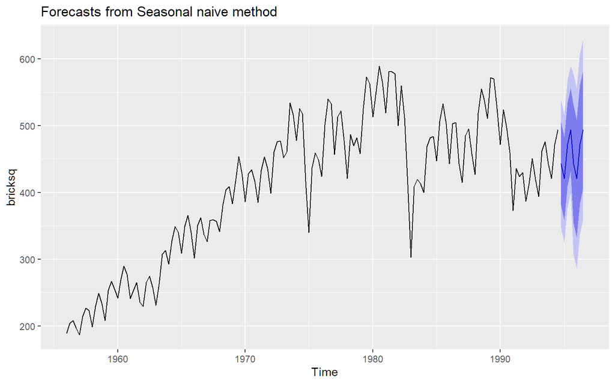

```r
fc <- snaive(bricksq)
autoplot(fc)
```

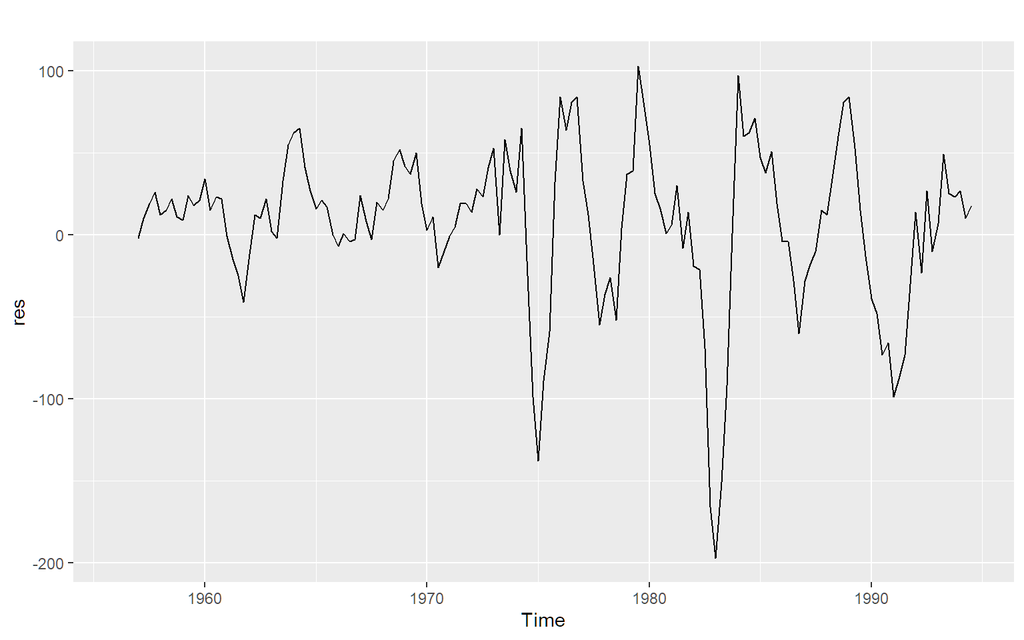

```r
res <- residuals(fc)
autoplot(res)
```

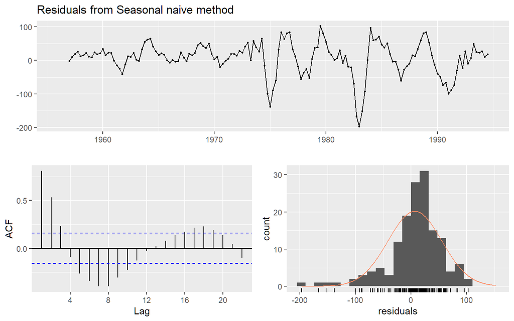

```
##
##  Ljung-Box test
##
## data:  Residuals from Seasonal naive method
## Q* = 233, df = 8, p-value <2e-16
##
## Model df: 0.   Total lags used: 8
```

```r
checkresiduals(fc)
```

# 5 [9 points] Forecasting IBM’s closing price

The dataset `ibmclose` contains the daily closing IBM stock price.

1. [1 point] Plot the data to become familiar with it
2. [1 point] Split the data into a training set of 300 observations and a test set of 69 observations.
3. [1 point] Plot `ibmclose` labeling the “training” and “test” series
4. [2 points] Create a plot showing the `ibmclose` dataset with each of the naive, mean and drift benchmarks. Use a forecast interval equal to the size of the test interval.
5. [2 points] Compare the `accuracy` of each of the naive, mean and drift benchmarks with the test dataset. Which has the smallest MASE?
6. [2 points] Using the benchmark with lowest MASE, check its residuals? Does it resemble random noise?

## 5.1 [9 points] Solution: Forecasting IBM’s closing price

### 5.1.1 [1 point] Plot the data to become familiar with it

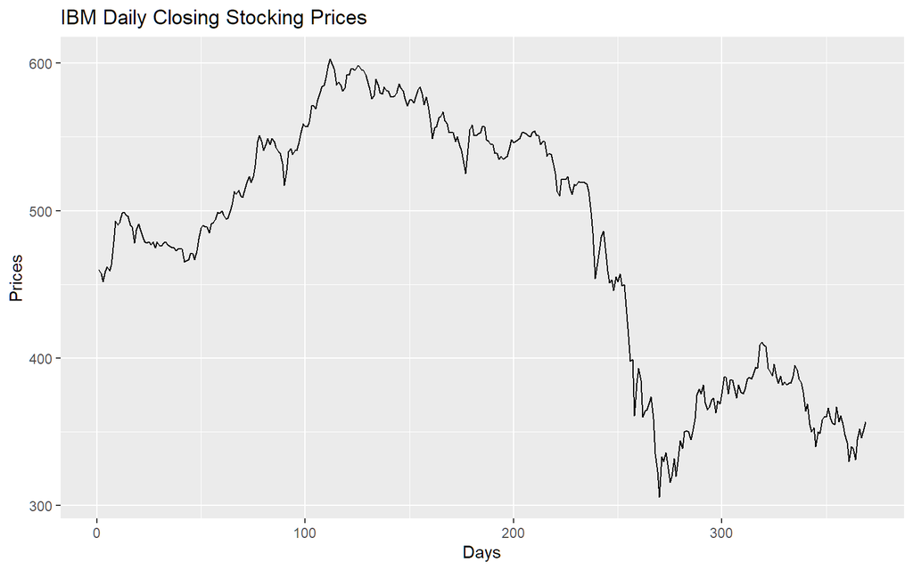

```r
autoplot(ibmclose) + ggtitle("IBM Daily Closing Stocking Prices") + xlab("Days") + ylab("Prices")
```

### 5.1.2 [1 point] Split the data into a training set of 300 observations and a test set of 69 observations.

```r
ibm_train_data <- window(ibmclose,end=c(300))
ibm_test_data <- window(ibmclose,start=c(301))
```

### 5.1.3 [1 point] Plot `ibmclose` labeling the “training” and “test” series

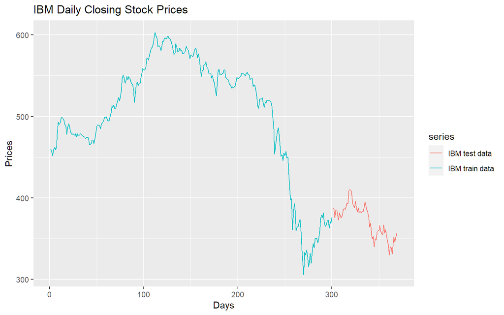

```r
autoplot(ibm_train_data, series = "IBM train data") +
  autolayer(ibm_test_data, series = "IBM test data") +
  ggtitle("IBM Daily Closing Stock Prices") +
  xlab("Days") + ylab("Prices")
```

### 5.1.4 [2 points] Create a plot showing the `ibmclose` dataset with each of the naive, mean and drift benchmarks. Use a forecast interval equal to the size of the test interval.

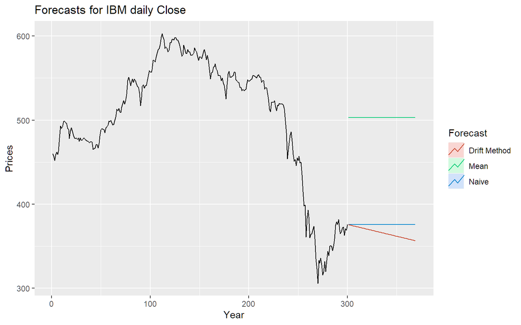

```r
# Calculate h-value
h <- length(ibm_test_data)

# Calculate naive, mean and drift benchmarks
ibm_naive <- naive(ibm_train_data, h=h)
ibm_mean <- meanf(ibm_train_data, h=h)
ibm_drift <- rwf(ibm_train_data, h=h, drift=TRUE)

#Plotting the forecasts
autoplot(ibm_train_data) +
  autolayer(ibm_naive,
    series="Naive", PI=FALSE) +
  autolayer(ibm_mean,
    series="Mean", PI=FALSE) +
  autolayer(ibm_drift,
    series="Drift Method", PI=FALSE) +
  ggtitle("Forecasts for IBM daily Close") +
  xlab("Year") + ylab("Prices") +
  guides(colour=guide_legend(title="Forecast"))
```

### 5.1.5 [2 points] Compare the `accuracy` of each of the naive, mean and drift benchmarks with the test dataset. Which has the smallest MASE?

```r
# Calculating the accuracy
accuracy(ibm_naive, ibm_test_data)
```

```
##                    ME    RMSE    MAE       MPE   MAPE  MASE    ACF1 Theil's U
## Training set -0.28094  7.3028  5.097 -0.082629 1.1158 1.000 0.13511        NA
## Test set     -3.72464 20.2481 17.029 -1.293917 4.6682 3.341 0.93147    2.9735
```

```r
accuracy(ibm_mean, ibm_test_data)
```

```
##                       ME    RMSE     MAE      MPE   MAPE   MASE    ACF1
## Training set  1.6604e-14  73.615  58.722  -2.6421 13.030 11.521 0.98958
## Test set     -1.3062e+02 132.126 130.618 -35.4788 35.479 25.626 0.93147
##              Theil's U
## Training set        NA
## Test set        19.055
```

```r
accuracy(ibm_drift,ibm_test_data)
```

```
##                      ME    RMSE    MAE       MPE   MAPE   MASE    ACF1
## Training set 2.8705e-14  7.2974  5.128 -0.025301 1.1217 1.0061 0.13511
## Test set     6.1081e+00 17.0670 13.975  1.419201 3.7079 2.7418 0.90459
##              Theil's U
## Training set        NA
## Test set        2.3611
```

> Answer:

> The smallest MASE value is on the drift forecast.

### 5.1.6 [2 points] Using the benchmark with lowest MASE, check its residuals. Does it resemble random noise?

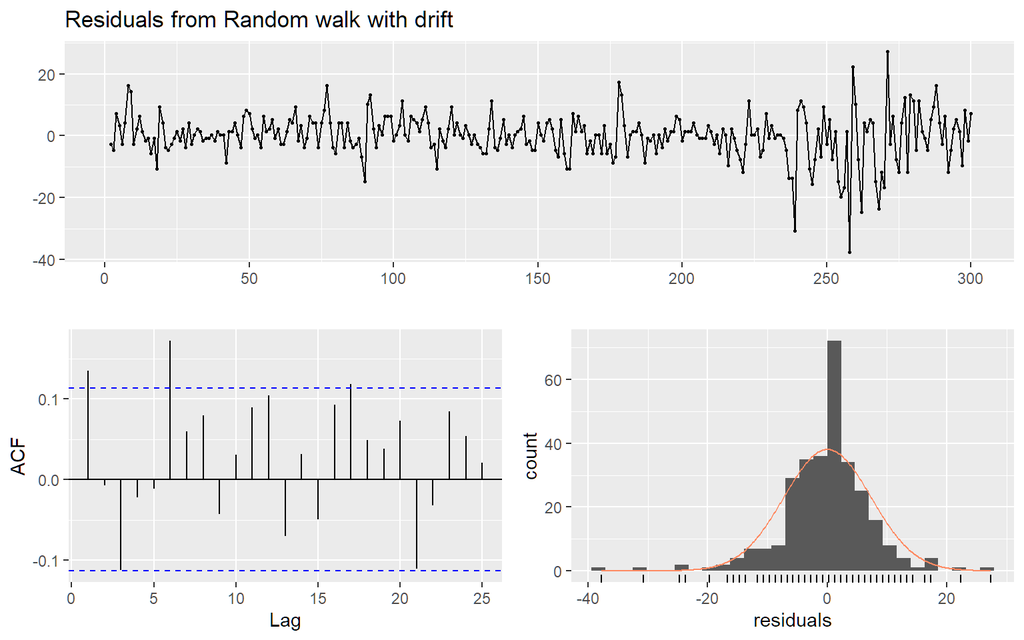

```
##
##  Ljung-Box test
##
## data:  Residuals from Random walk with drift
## Q* = 22.6, df = 9, p-value = 0.0073
##
## Model df: 1.   Total lags used: 10
```

```r
# checkresiduals of benchmark with lowest MASE
checkresiduals(ibm_drift)
```

> Does it resemble random noise?

> No, it does not resemble white noise (3/25 = 0.12 = 12%).